# Project Python Foundations: FoodHub Data Analysis

### Context

The number of restaurants in New York is increasing day by day. Lots of students and busy professionals rely on those restaurants due to their hectic lifestyles. Online food delivery service is a great option for them. It provides them with good food from their favorite restaurants. A food aggregator company FoodHub offers access to multiple restaurants through a single smartphone app.

The app allows the restaurants to receive a direct online order from a customer. The app assigns a delivery person from the company to pick up the order after it is confirmed by the restaurant. The delivery person then uses the map to reach the restaurant and waits for the food package. Once the food package is handed over to the delivery person, he/she confirms the pick-up in the app and travels to the customer's location to deliver the food. The delivery person confirms the drop-off in the app after delivering the food package to the customer. The customer can rate the order in the app. The food aggregator earns money by collecting a fixed margin of the delivery order from the restaurants.

### Objective

The food aggregator company has stored the data of the different orders made by the registered customers in their online portal. They want to analyze the data to get a fair idea about the demand of different restaurants which will help them in enhancing their customer experience. Suppose you are hired as a Data Scientist in this company and the Data Science team has shared some of the key questions that need to be answered. Perform the data analysis to find answers to these questions that will help the company to improve the business.

### Data Description

The data contains the different data related to a food order. The detailed data dictionary is given below.

### Data Dictionary

- order_id: Unique ID of the order
- customer_id: ID of the customer who ordered the food
- restaurant_name: Name of the restaurant
- cuisine_type: Cuisine ordered by the customer
- cost_of_the_order: Cost of the order
- day_of_the_week: Indicates whether the order is placed on a weekday or weekend (The weekday is from Monday to Friday and the weekend is Saturday and Sunday)
- rating: Rating given by the customer out of 5
- food_preparation_time: Time (in minutes) taken by the restaurant to prepare the food. This is calculated by taking the difference between the timestamps of the restaurant's order confirmation and the delivery person's pick-up confirmation.
- delivery_time: Time (in minutes) taken by the delivery person to deliver the food package. This is calculated by taking the difference between the timestamps of the delivery person's pick-up confirmation and drop-off information

### Let us start by importing the required libraries

```python
# Installing the libraries with the specified version.
!pip install numpy==1.25.2 pandas==2.2.2 matplotlib==3.8.0 seaborn==0.13.1 -q --user
```

```
   ━━━━━━━━━━━━━━━━━━━━━━━━━━━━━━━━━━━━━━━━ 11.6/11.6 MB 71.7 MB/s eta 0:00:00
```

**Note**: *After running the above cell, kindly restart the notebook kernel and run all cells sequentially from the start again.*

```python
# import libraries for data manipulation
import numpy as np
import pandas as pd

# import libraries for data visualization
import matplotlib.pyplot as plt
import seaborn as sns
```

### Understanding the structure of the data

```python
# uncomment and run the following lines for Google Colab
from google.colab import drive
drive.mount('/content/drive')
```

```python
# read the data from the drive
import pandas as pd
df = pd.read_csv('/content/drive/MyDrive/foodhub_order.csv')
```

```python
# view the first five rows of the dataset
df.head()
```

|  | order_id | customer_id | restaurant_name | cuisine_type | cost_of_the_order | day_of_the_week | rating | food_preparation_time | delivery_time |
| --- | --- | --- | --- | --- | --- | --- | --- | --- | --- |
| 0 | 1477147 | 337525 | Hangawi | Korean | 30.75 | Weekend | Not given | 25 | 20 |
| 1 | 1477685 | 358141 | Blue Ribbon Sushi Izakaya | Japanese | 12.08 | Weekend | Not given | 25 | 23 |
| 2 | 1477070 | 66393 | Cafe Habana | Mexican | 12.23 | Weekday | 5 | 23 | 28 |
| 3 | 1477334 | 106968 | Blue Ribbon Fried Chicken | American | 29.20 | Weekend | 3 | 25 | 15 |
| 4 | 1478249 | 76942 | Dirty Bird to Go | American | 11.59 | Weekday | 4 | 25 | 24 |

### **Question 1:** How many rows and columns are present in the data? [0.5 mark]

```python
# provides dimensions of the data frame
df.shape
```

```
(1898, 9)
```

### **Question 2:** What are the datatypes of the different columns in the dataset? (The info() function can be used) [0.5 mark]

```python
# provide a concise summary of the data frame's structure
df.info()
```

```
<class 'pandas.core.frame.DataFrame'>
RangeIndex: 1898 entries, 0 to 1897
Data columns (total 9 columns):
 #   Column                 Non-Null Count  Dtype
---  ------                 --------------  -----
 0   order_id               1898 non-null   int64
 1   customer_id            1898 non-null   int64
 2   restaurant_name        1898 non-null   object
 3   cuisine_type           1898 non-null   object
 4   cost_of_the_order      1898 non-null   float64
 5   day_of_the_week        1898 non-null   object
 6   rating                 1898 non-null   object
 7   food_preparation_time  1898 non-null   int64
 8   delivery_time          1898 non-null   int64
dtypes: float64(1), int64(4), object(4)
memory usage: 133.6+ KB
```

#### Observations:

#### The function will output the number of rows, the column names, the data types of each column, the number of non-null entries, and the memeory usage.

### **Question 3:** Are there any missing values in the data? If yes, treat them using an appropriate method. [1 mark]

```python
# Separate numerical and categorical columns
numerical_cols = df.select_dtypes(include=['number']).columns
categorical_cols = df.select_dtypes(include=['object']).columns

# Fill missing values for numerical columns with median
df[numerical_cols] = df[numerical_cols].fillna(df[numerical_cols].median())

# Fill missing values for categorical columns with mode
for col in categorical_cols:
    mode_value = df[col].mode()
    if not mode_value.empty:
        df[col] = df[col].fillna(mode_value[0])
```

#### Median is used for numerical columns; fills the missing values with median value of each column.

#### Mode is used for categorical columns; fills the missing values with that of the most commonly used restaurant name.

### **Question 4:** Check the statistical summary of the data. What is the minimum, average, and maximum time it takes for food to be prepared once an order is placed? [2 marks]

```python
# statistic summary for numerical columns
df.describe()

#extracting information about food preparation time
food_prep_stats = df['food_preparation_time'].describe()
food_prep_stats[['min', 'mean', 'max']]
```

|  | food_preparation_time |
| --- | --- |
| min | 20.00000 |
| mean | 27.37197 |
| max | 35.00000 |

**dtype:** float64

#### Calling the describe() function will allow you to extract information about the food_preperation_time, to get min, mean, and max.

#### The values help to understand the range of time it takes for restaurants to prepare the food after an order is placed, which can be useful for improving operational efficiency or managing customer expectations.

### **Question 5:** How many orders are not rated? [1 mark]

```python
# counting orders with no ratings
unrated_orders = df[df['rating'].isnull()]
unrated_orders.shape[0]
```

```
0
```

#### Observations:

#### Helpful to see what restaurants don't get a lot of customer interaction on the app.

### Exploratory Data Analysis (EDA)

### **Question 6:** Explore all the variables and provide observations on their distributions. (Generally, histograms, boxplots, countplots, etc. are used for univariate exploration.) [9 marks]

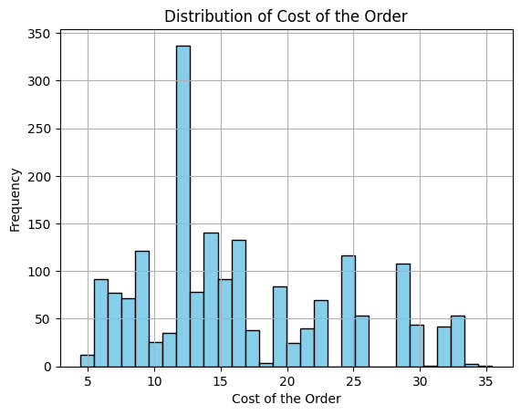

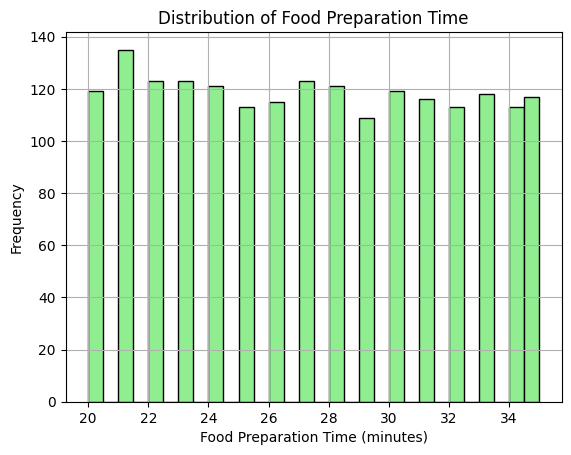

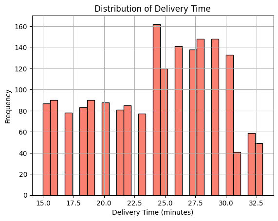

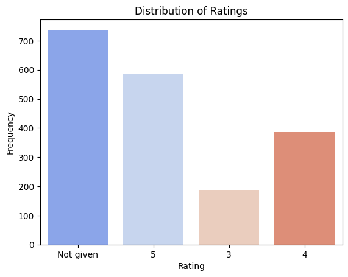

```python
# COST OF ORDER
# plotting a histogram to see how the order costs are distributed
df['cost_of_the_order'].hist(bins=30, color='skyblue', edgecolor='black')
plt.title('Distribution of Cost of the Order')
plt.xlabel('Cost of the Order')
plt.ylabel('Frequency')
plt.show()

# FOOD PREPERATION TIME
# visualizing the time it takes for restaurants to prepare food after order is placed
df['food_preparation_time'].hist(bins=30, color='lightgreen', edgecolor='black')
plt.title('Distribution of Food Preparation Time')
plt.xlabel('Food Preparation Time (minutes)')
plt.ylabel('Frequency')
plt.show()

# DELIVERY TIME
# visualizing how long it takes for delivery including both preparation and delivery time
df['delivery_time'].hist(bins=30, color='salmon', edgecolor='black')
plt.title('Distribution of Delivery Time')
plt.xlabel('Delivery Time (minutes)')
plt.ylabel('Frequency')
plt.show()

# VISUALIZING DISTRIBUTION OF CATEGORICAL VALUES
# creating a countplot to show frequency of each rating
sns.countplot(x='rating', data=df, palette='coolwarm')
plt.title('Distribution of Ratings')
plt.xlabel('Rating')
plt.ylabel('Frequency')
plt.show()
```

### **Question 7**: Which are the top 5 restaurants in terms of the number of orders received? [1 mark]

```python
# counting orders per restaurant
top_restaurants = df['restaurant_name'].value_counts().head(5)
top_restaurants
```

| restaurant_name | count |
| --- | --- |
| Shake Shack | 219 |
| The Meatball Shop | 132 |
| Blue Ribbon Sushi | 119 |
| Blue Ribbon Fried Chicken | 96 |
| Parm | 68 |

**dtype:** int64

#### Observations:

#### The output lists the top 5 restaurants with the most order counts, by returning both restaurant name and number of orders.

#### Can be helpful to put in a category on the app for "trending".

### **Question 8**: Which is the most popular cuisine on weekends? [1 mark]

```python
# Filter data for weekends
weekend_orders = df[df['day_of_the_week'].isin(['Weekend'])]

# Check if there are any weekend orders
if weekend_orders.empty:
    print("No weekend orders found.")
else:
    # Get the most popular cuisine on weekends
    most_popular_cuisine = weekend_orders['cuisine_type'].value_counts().head(1)

    # Get the cuisine name and its count if there are values
    if not most_popular_cuisine.empty:
        cuisine_name = most_popular_cuisine.index[0]  # Name of the most popular cuisine
        cuisine_count = most_popular_cuisine.iloc[0]   # Count of the most popular cuisine

        # Display the result
        print(f"The most popular cuisine on weekends is {cuisine_name} with {cuisine_count} orders.")
    else:
        print("No cuisine data found for weekends.")
```

```
The most popular cuisine on weekends is American with 415 orders.
```

#### Observations:

#### The insight can be valuable for marketing purposes or to decide which restaurants to promote on weekends.

### **Question 9**: What percentage of the orders cost more than 20 dollars? [2 marks]

```python
# filtering orders with cost greater than 20
orders_above_20 = df[df['cost_of_the_order'] > 20]

# calculating the percentage of orders with cost greater than 20
percentage_above_20 = (orders_above_20.shape[0] / df.shape[0]) * 100
percentage_above_20
```

```
29.24130663856691
```

#### Observations:

#### The calculation provides insight into the distribution of order costs and can help the company understand the proportion of high-value orders.

#### If the percentage is low, the company may want to consider offering more premium options or targeting marketing towards customers who prefer higher-cost items.

### **Question 10**: What is the mean order delivery time? [1 mark]

```python
# selects delivery_time column from data frame and calculates the mean delivery time
mean_delivery_time = df['delivery_time'].mean()

# display the result
mean_delivery_time
```

```
24.161749209694417
```

#### Observations:

#### The mean delivery time gives us a sense of the average efficiency

#### If the mean delivery time is high, it could indicate that delivery is taking longer than expected, which may lead to customer dissatisfaction, therefore, company might want to focus on improving logistics and route optimization to reduce delivery times and improve customer satisfaction.

#### Understanding the mean helps the company set realistic expectations for customers regarding delivery times.

### **Question 11:** The company has decided to give 20% discount vouchers to the top 3 most frequent customers. Find the IDs of these customers and the number of orders they placed. [1 mark]

```python
# counting orders per customer
top_customers = df['customer_id'].value_counts().head(3)

# display the top 3 customers and their order count
top_customers
```

| customer_id | count |
| --- | --- |
| 52832 | 13 |
| 47440 | 10 |
| 83287 | 9 |

**dtype:** int64

#### Observations:

#### By identifying the top 3 customers, the company can target them for promotional offers such as the 20% discount vouchers.

#### These customers have demonstrated a high level of engagement with the service, and rewarding them can help further improve customer loyalty.

### **Question 12**: Perform a multivariate analysis to explore relationships between the important variables in the dataset. (It is a good idea to explore relations between numerical variables as well as relations between numerical and categorical variables) [10 marks]

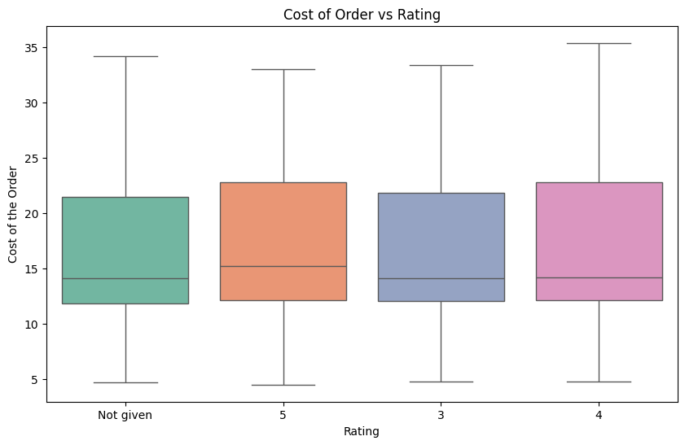

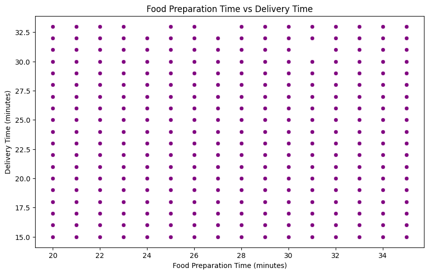

```python
# cost vs rating - boxplot
plt.figure(figsize=(10,6))
sns.boxplot(x='rating', y='cost_of_the_order', data=df, palette='Set2')
plt.title('Cost of Order vs Rating')
plt.xlabel('Rating')
plt.ylabel('Cost of the Order')
plt.show()

# delivery time vs food preparation time - scatterplot
plt.figure(figsize=(10,6))
sns.scatterplot(x='food_preparation_time', y='delivery_time', data=df, color='purple')
plt.title('Food Preparation Time vs Delivery Time')
plt.xlabel('Food Preparation Time (minutes)')
plt.ylabel('Delivery Time (minutes)')
plt.show()
```

### **Question 13:** The company wants to provide a promotional offer in the advertisement of the restaurants. The condition to get the offer is that the restaurants must have a rating count of more than 50 and the average rating should be greater than 4. Find the restaurants fulfilling the criteria to get the promotional offer. [3 marks]

```python
# Convert 'rating' column to numeric, handling errors
df['rating'] = pd.to_numeric(df['rating'], errors='coerce')

# aggregating by restaurant to get rating count and average rating
restaurant_ratings = df.groupby('restaurant_name').agg(
    rating_count=('rating', 'count'),
    avg_rating=('rating', 'mean')
)

# filtering restaurants that satisfy the conditions
promotional_restaurants = restaurant_ratings[
    (restaurant_ratings['rating_count'] > 50) &
    (restaurant_ratings['avg_rating'] > 4)
]
# display the restaurants that fulfill the conditions
promotional_restaurants
```

| restaurant_name | rating_count | avg_rating |
| --- | --- | --- |
| Blue Ribbon Fried Chicken | 64 | 4.328125 |
| Blue Ribbon Sushi | 73 | 4.219178 |
| Shake Shack | 133 | 4.278195 |
| The Meatball Shop | 84 | 4.511905 |

#### Observations:

#### Rating Count > 50: This ensures that the restaurant has enough ratings to be considered reliable. A restaurant with fewer than 50 ratings might not have enough data to be statistically meaningful.

#### Average Rating > 4: This ensures that only restaurants with consistently high ratings are included in the offer.

#### By offering a promotional deal only to restaurants with high ratings and a sufficient number of reviews, the company ensures that the advertisement will promote high-quality establishments that are well-received by customers.

#### Customers will trust the promotional offers more if they are for restaurants that have been highly rated by a large number of users.

### **Question 14:** The company charges the restaurant 25% on the orders having cost greater than 20 dollars and 15% on the orders having cost greater than 5 dollars. Find the net revenue generated by the company across all orders. [3 marks]

```python
# calculating the revenue for each order
df['revenue'] = np.where(df['cost_of_the_order'] > 20,
                          df['cost_of_the_order'] * 0.25,
                          np.where(df['cost_of_the_order'] > 5,
                                   df['cost_of_the_order'] * 0.15,
                                   0))

# total revenue
total_revenue = df['revenue'].sum()
total_revenue
```

```
6166.303
```

#### Observations:

- The company earns higher revenue from orders with a cost greater than 20 dollars because the percentage charged is higher at 25%.
- Orders with costs between 5 dollars and 20 dollars contribute to a smaller revenue (15% charge).
- Orders with costs below 5 dollars contribute no revenue.
- By calculating the net revenue, the company can assess how much money it is earning from its revenue model based on the order cost.

### **Question 15:** The company wants to analyze the total time required to deliver the food. What percentage of orders take more than 60 minutes to get delivered from the time the order is placed? (The food has to be prepared and then delivered.) [2 marks]

```python
# calculating total time to deliver the food (prep time + delivery time)
df['total_time'] = df['food_preparation_time'] + df['delivery_time']

# percentage of orders taking more than 60 minutes
orders_above_60 = df[df['total_time'] > 60]
percentage_above_60 = (orders_above_60.shape[0] / df.shape[0]) * 100
percentage_above_60
```

```
10.537407797681771
```

#### Observations:

#### By analyzing the percentage of orders taking more than 60 minutes, the company can assess its operational efficiency. If a large percentage of orders are taking too long to be delivered, it may indicate issues in either food preparation times or delivery logistics.

#### Orders taking longer than expected to be delivered can negatively affect customer satisfaction. Identifying the percentage of such orders allows the company to take corrective actions.

#### If the percentage of orders taking longer than 60 minutes is high, the company may decide to focus on improving food preparation or delivery time to enhance overall service quality.

### **Question 16:** The company wants to analyze the delivery time of the orders on weekdays and weekends. How does the mean delivery time vary during weekdays and weekends? [2 marks]

```python
# grouping by day_of_the_week and calculating the mean delivery time for each group
weekday_vs_weekend = df.groupby('day_of_the_week')['delivery_time'].mean()
# displaying the mean delivery time for weekdays and weekends
weekday_vs_weekend
```

| day_of_the_week | delivery_time |
| --- | --- |
| Weekday | 28.340037 |
| Weekend | 22.470022 |

**dtype:** float64

#### Observations:

#### If the delivery time is longer on weekends, the company might want to investigate whether there are more orders on weekends, whether delivery personnel are available in sufficient numbers, or whether there are external factors (e.g., traffic, weather) causing delays.

#### If delivery times are longer on weekends, it may lead to customer dissatisfaction. The company could consider taking actions like increasing the number of delivery personnel during peak times or improving logistics to ensure faster delivery.

#### Understanding how delivery time varies between weekdays and weekends can inform the company’s strategy in managing deliveries, optimizing staff schedules, and making improvements to the delivery process.